# IBM Employee Attribution

Team 5

2025-05-11

```r
rm(list = ls())     # clear the workspace
library(ISLR)       # load ISLR data package
library(tidyverse)
```

```r
library(ggplot2)
library(rpart)
library(rpart.plot)
library(randomForest)
library(pROC)
library(e1071)
library(gbm)
library(caret)
library(car)
library(corrplot)
Employeedata<- read.csv("Employee_Attrition.csv") # Load the original dataset
#dim(Employeedata) # Check the shape of the dataset
#cat("\n")
#summary(Employeedata)# View summary statistics for each variable
#cat("\n")
#str(Employeedata)#Showed the structure and data types of each column

#Clearing
colSums(is.na(Employeedata))# Check for missing values in each column
```

```
##                      Age                Attrition           BusinessTravel
##                        0                        0                        0
##                DailyRate               Department         DistanceFromHome
##                        0                        0                        0
##                Education           EducationField            EmployeeCount
##                        0                        0                        0
##           EmployeeNumber  EnvironmentSatisfaction                   Gender
##                        0                        0                        0
##               HourlyRate           JobInvolvement                 JobLevel
##                        0                        0                        0
##                  JobRole          JobSatisfaction            MaritalStatus
##                        0                        0                        0
##            MonthlyIncome              MonthlyRate       NumCompaniesWorked
##                        0                        0                        0
##                   Over18                 OverTime        PercentSalaryHike
##                        0                        0                        0
##        PerformanceRating RelationshipSatisfaction            StandardHours
##                        0                        0                        0
##         StockOptionLevel        TotalWorkingYears    TrainingTimesLastYear
##                        0                        0                        0
##          WorkLifeBalance           YearsAtCompany       YearsInCurrentRole
##                        0                        0                        0
##  YearsSinceLastPromotion     YearsWithCurrManager
##                        0                        0
```

```r
which(duplicated(Employeedata)) # Check duplicated rows
```

```
## integer(0)
```

```r
single_value_cols <- names(Employeedata)[sapply(Employeedata, function(x) length(unique(x)) == 1)]# Check columns with only one unique value
#print(single_value_cols)

Employeedata <- Employeedata[, sapply(Employeedata, function(x) length(unique(x)) > 1)] # Drop Useless Feature
single_value_cols <- names(Employeedata)[sapply(Employeedata, function(x) length(unique(x)) == 1)]# Check columns with only one unique value
#print(single_value_cols)

# Encoding
char_cols <- names(Employeedata)[sapply(Employeedata, is.character)]
char_cols #Identify all character columns
```

```
## [1] "Attrition"      "BusinessTravel" "Department"     "EducationField"
## [5] "Gender"         "JobRole"        "MaritalStatus"  "OverTime"
```

```r
cat("\n")
```

```r
char_vars <- Employeedata[, sapply(Employeedata, is.character)]
lapply(char_vars, unique) # Show unique values for each categorical column
```

```
## $Attrition
## [1] "Yes" "No"
##
## $BusinessTravel
## [1] "Travel_Rarely"     "Travel_Frequently" "Non-Travel"
##
## $Department
## [1] "Sales"                  "Research & Development" "Human Resources"
##
## $EducationField
## [1] "Life Sciences"    "Other"            "Medical"          "Marketing"
## [5] "Technical Degree" "Human Resources"
##
## $Gender
## [1] "Female" "Male"
##
## $JobRole
## [1] "Sales Executive"           "Research Scientist"
## [3] "Laboratory Technician"     "Manufacturing Director"
## [5] "Healthcare Representative" "Manager"
## [7] "Sales Representative"      "Research Director"
## [9] "Human Resources"
##
## $MaritalStatus
## [1] "Single"   "Married"  "Divorced"
##
## $OverTime
## [1] "Yes" "No"
```

```r
#[1, 0] encoding
Employeedata$Attrition <- ifelse(Employeedata$Attrition == "Yes", 1, 0)
Employeedata$OverTime <- ifelse(Employeedata$OverTime == "Yes", 1, 0)
Employeedata$Gender   <- ifelse(Employeedata$Gender == "Male", 1, 0)

# Ranking
Employeedata$BusinessTravel <- ifelse(Employeedata$BusinessTravel == "Non-Travel", 0, ifelse(Employeedata$BusinessTravel == "Travel_Rarely", 1, 2))

# One-Hot encoding
edu_matrix <- model.matrix(~ EducationField - 1, data = Employeedata)

job_matrix <- model.matrix(~ JobRole - 1, data = Employeedata)

dept_matrix <- model.matrix(~ Department - 1, data = Employeedata)

marital_matrix <- model.matrix(~ MaritalStatus - 1, data = Employeedata)

onehot_encoded <- cbind(edu_matrix, job_matrix, dept_matrix, marital_matrix)


Employeedata_encoded <- cbind(Employeedata[, !(names(Employeedata) %in% c("EducationField", "JobRole", "Department", "MaritalStatus"))],
                    onehot_encoded)
Employeedata_encoded <- Employeedata_encoded[, !(names(Employeedata_encoded) %in% "EmployeeNumber")] #This is a unique ID column for employees; drop it as it's not useful for modeling.

#Employeedata_encoded

dim(Employeedata_encoded)
```

```
## [1] 1470   48
```

```r
# Scaling

cols_to_scale <- c("DailyRate","DistanceFromHome","PercentSalaryHike", "HourlyRate",
                   "YearsAtCompany", "MonthlyIncome", "MonthlyRate", "NumCompaniesWorked",
                   "TotalWorkingYears", "TrainingTimesLastYear", "YearsInCurrentRole",
                   "YearsSinceLastPromotion", "YearsWithCurrManager")

#Before scaling, we check the skewness of each column to decide if transformation is needed.
skew_df <- data.frame(
  Variable = cols_to_scale ,
  Skewness = sapply(Employeedata_encoded[cols_to_scale ], skewness, na.rm = TRUE)
)
skew_df <- skew_df[order(-abs(skew_df$Skewness)), ]
#skew_df

cols_to_log <- c("YearsSinceLastPromotion", "YearsAtCompany", "MonthlyIncome", "TotalWorkingYears","DistanceFromHome","YearsInCurrentRole","NumCompaniesWorked"
,"YearsWithCurrManager","PercentSalaryHike")

sapply(Employeedata_encoded[cols_to_log], function(x) any(x < 0, na.rm = TRUE)) # Check 0
```

```
## YearsSinceLastPromotion          YearsAtCompany           MonthlyIncome
##                   FALSE                   FALSE                   FALSE
##       TotalWorkingYears        DistanceFromHome      YearsInCurrentRole
##                   FALSE                   FALSE                   FALSE
##      NumCompaniesWorked    YearsWithCurrManager       PercentSalaryHike
##                   FALSE                   FALSE                   FALSE
```

```r
for (col in cols_to_log) {
  Employeedata_encoded[[col]] <- scale(log(Employeedata_encoded[[col]] + 1))
}

skew_df <- data.frame(
  Variable = cols_to_scale ,
  Skewness = sapply(Employeedata_encoded[cols_to_scale ], skewness, na.rm = TRUE)
)
skew_df <- skew_df[order(-abs(skew_df$Skewness)), ]
skew_df
```

```
##                                        Variable     Skewness
## YearsSinceLastPromotion YearsSinceLastPromotion  0.717338270
## TotalWorkingYears             TotalWorkingYears -0.620905697
## TrainingTimesLastYear     TrainingTimesLastYear  0.551995858
## PercentSalaryHike             PercentSalaryHike  0.512494951
## YearsInCurrentRole           YearsInCurrentRole -0.382715447
## YearsWithCurrManager       YearsWithCurrManager -0.356956019
## MonthlyIncome                     MonthlyIncome  0.285864053
## YearsAtCompany                   YearsAtCompany -0.207284251
## NumCompaniesWorked           NumCompaniesWorked  0.092706726
## HourlyRate                           HourlyRate -0.032245042
## DistanceFromHome               DistanceFromHome -0.029061382
## MonthlyRate                         MonthlyRate  0.018539911
## DailyRate                             DailyRate -0.003511391
```

```r
Employeedata_encoded_scaled <- Employeedata_encoded
Employeedata_encoded_scaled[cols_to_scale] <- scale(Employeedata_encoded[cols_to_scale])
#Employeedata_encoded_scaled

# pre-SMOTE check
#table(Employeedata_encoded_scaled$Attrition)

# Multicollinearity check

cor_matrix <- cor(Employeedata_encoded_scaled, use = "complete.obs")
cor_df <- as.data.frame(as.table(cor_matrix))
cor_df <- subset(cor_df, Var1 != Var2)
cor_df$pair <- apply(cor_df[,1:2], 1, function(x) paste(sort(x), collapse = "_"))
cor_df <- cor_df[!duplicated(cor_df$pair), ]
high_corr_df <- subset(cor_df, abs(Freq) > 0.75)
high_corr_df <- high_corr_df[, c("Var1", "Var2", "Freq")]
colnames(high_corr_df) <- c("var1", "var2", "correlation")
#print(high_corr_df)

Employeedata_encoded_scaled<- Employeedata_encoded_scaled[, !(names(Employeedata_encoded_scaled) %in% c("JobLevel", "YearsAtCompany"))]
write.csv(Employeedata_encoded_scaled, "Employeedata_encoded_scaled.csv", row.names = FALSE)
```

```r
df_e<-Employeedata_encoded_scaled
df_e$Attrition <- factor(df_e$Attrition, levels = c(0, 1), labels = c("No", "Yes"))
names(df_e) <- make.names(names(df_e))
```

# rf with hold-out validation

This level of imbalance (5.2:1) is moderate—not extreme but definitely significant enough to impact your model’s performance:

Biased Predictions: Tree models trained on imbalanced data tend to favor the majority class because predicting the majority class leads to higher accuracy. Performance Metrics Misinterpretation: Accuracy becomes misleading. A model that always predicts the majority class would achieve 84% accuracy in our example, but be useless for identifying minority class instances. Impact on Tree Structure: Decision trees optimize for purity measures (Gini impurity or entropy), which can lead them to ignore minority class patterns. Cross-Validation Effects: The imbalance may be distributed unevenly across CV folds, contributing to the performance gap you observed.

```r
set.seed(123)
train_indices <- createDataPartition(df_e$Attrition, p = 0.7, list = FALSE)

train_data <- df_e[train_indices, ]
test_data <- df_e[-train_indices, ]

attrition_table <- table(train_data$Attrition)
imbalance_ratio <- attrition_table["No"] / attrition_table["Yes"]
cat("Class imbalance ratio (No:Yes):", imbalance_ratio, "\n")
```

```
## Class imbalance ratio (No:Yes): 5.204819
```

findout: ntree, nodesize, parameter does not bring significant change to the model result but the change of threshold has apparent impacts on the trade-off between accuracy and senstivity. Otherwise, In order to address the class imbalance problem, i have add class weight parameter (1:5.2) when building the model. It shows counterintuitive result that shows even lower performances especially the obvious drop of AUC value.The potential reason is that getting high sensitivity will also cause overfit to the minority class by adjusting the class weight.

```r
set.seed(123)
rf_model <- randomForest(
  Attrition~.,
  data = train_data,
  ntree = 100,
  nodesize = 3,
  #classwt = c(1, 5.2),
  cutoff = c(0.81, 0.19),
  importance = TRUE
)

predictions <- predict(rf_model, newdata = test_data)
conf_matrix <- confusionMatrix(predictions, test_data$Attrition, positive = "Yes")
print(conf_matrix)
```

```
## Confusion Matrix and Statistics
##
##           Reference
## Prediction  No Yes
##        No  269  18
##        Yes 100  53
##
##                Accuracy : 0.7318
##                  95% CI : (0.6878, 0.7727)
##     No Information Rate : 0.8386
##     P-Value [Acc > NIR] : 1
##
##                   Kappa : 0.3243
##
##  Mcnemar's Test P-Value : 8.875e-14
##
##             Sensitivity : 0.7465
##             Specificity : 0.7290
##          Pos Pred Value : 0.3464
##          Neg Pred Value : 0.9373
##              Prevalence : 0.1614
##          Detection Rate : 0.1205
##    Detection Prevalence : 0.3477
##       Balanced Accuracy : 0.7377
##
##        'Positive' Class : Yes
##
```

```r
# Get and display top 10 important features
importance_scores <- importance(rf_model)  # Extract feature importance from randomForest
importance_df <- as.data.frame(importance_scores)  # Convert to dataframe
importance_df$Feature <- rownames(importance_df)  # Add feature names as column
importance_df <- importance_df[order(importance_df$MeanDecreaseGini, decreasing = TRUE),]  # Sort by importance
head(importance_df[, c("Feature", "MeanDecreaseGini")], 10)  # Display top 10 features
```

```
##                                   Feature MeanDecreaseGini
## MonthlyIncome               MonthlyIncome        21.200448
## Age                                   Age        15.179021
## TotalWorkingYears       TotalWorkingYears        14.284248
## DailyRate                       DailyRate        13.993823
## HourlyRate                     HourlyRate        12.641103
## MonthlyRate                   MonthlyRate        12.273395
## DistanceFromHome         DistanceFromHome        12.058852
## OverTime                         OverTime        11.293850
## YearsWithCurrManager YearsWithCurrManager         9.622585
## PercentSalaryHike       PercentSalaryHike         8.574650
```

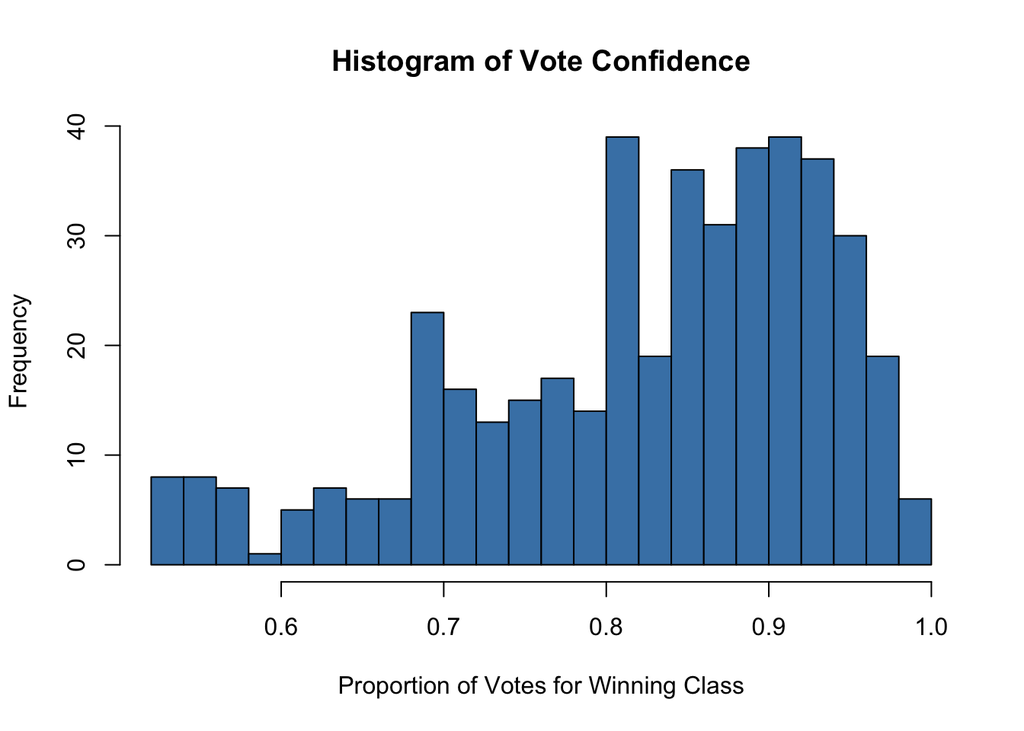

```r
# plot histogram of votes distribution
votes <- predict(rf_model, newdata = test_data, type = "vote")
votes_majority <- apply(votes, 1, function(x) max(x)/sum(x))  # Calculate proportion of majority votes
hist(votes_majority, breaks = 20, main = "Histogram of Vote Confidence",
     xlab = "Proportion of Votes for Winning Class", col = "steelblue")
```

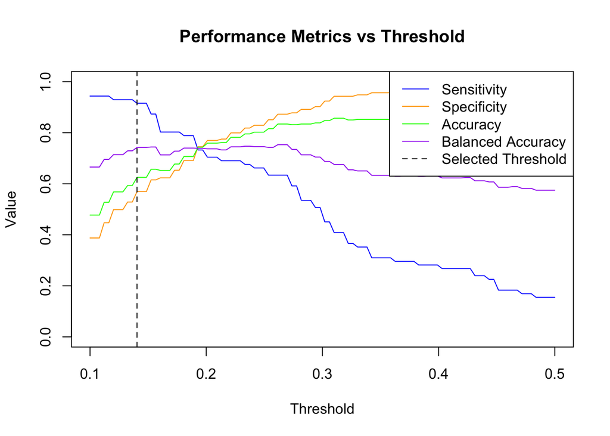

```r
#
# Get predicted probabilities
probs <- predict(rf_model, newdata = test_data, type = "prob")[,2]

# Calculate metrics across different thresholds
thresholds <- seq(0.1, 0.5, length.out = 100)
results <- data.frame(threshold = thresholds, sensitivity = NA, specificity = NA,
                     accuracy = NA, balanced_accuracy = NA)

for(i in 1:length(thresholds)) {
  preds <- ifelse(probs > thresholds[i], "Yes", "No")
  results$sensitivity[i] <- sum(preds == "Yes" & test_data$Attrition == "Yes") / sum(test_data$Attrition == "Yes")
  results$specificity[i] <- sum(preds == "No" & test_data$Attrition == "No") / sum(test_data$Attrition == "No")
  results$accuracy[i] <- sum(preds == test_data$Attrition) / length(test_data$Attrition)
  results$balanced_accuracy[i] <- (results$sensitivity[i] + results$specificity[i]) / 2
}

# Find optimal threshold balancing high sensitivity with reasonable accuracy
optimal_idx <- which.max(results$sensitivity * 0.55 + results$accuracy * 0.45)
optimal_threshold <- thresholds[optimal_idx]

# Plot the metrics
plot(thresholds, results$sensitivity, type="l", col="blue", ylim=c(0, 1),
     main="Performance Metrics vs Threshold", xlab="Threshold", ylab="Value")
lines(thresholds, results$specificity, col="orange")
lines(thresholds, results$accuracy, col="green")
lines(thresholds, results$balanced_accuracy, col="purple")
abline(v=optimal_threshold, lty=2)
legend("topright", legend=c("Sensitivity", "Specificity", "Accuracy", "Balanced Accuracy", "Selected Threshold"),
       col=c("blue", "orange", "green", "purple", "black"), lty=c(1,1,1,1,2))
```

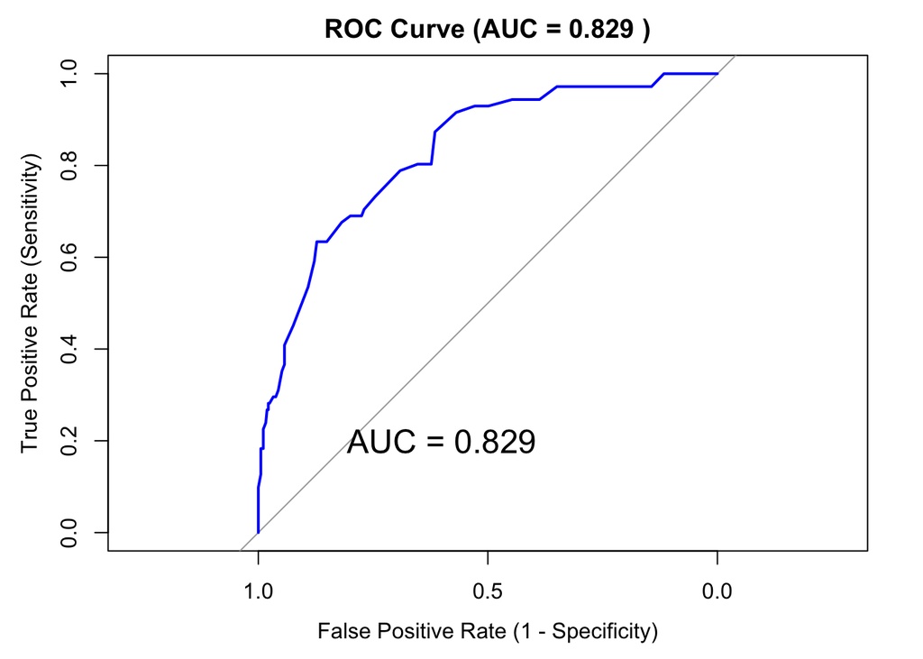

```r
# Plot ROC curve and display AUC value
probs <- predict(rf_model, newdata = test_data, type = "prob")[,2]  # Get probabilities for "Yes" class
roc_obj <- roc(test_data$Attrition, probs)
auc_value <- round(auc(roc_obj), 3)
plot(roc_obj, main = paste("ROC Curve (AUC =", auc_value, ")"),
     col = "blue", lwd = 2,
     xlab = "False Positive Rate (1 - Specificity)",
     ylab = "True Positive Rate (Sensitivity)")
text(0.6, 0.2, paste("AUC =", auc_value), cex = 1.5)
```

```r
# Create performance metrics table including threshold and AUC
threshold <- optimal_threshold  # Optimal threshold
probs <- predict(rf_model, newdata = test_data, type = "prob")[,2]
predictions <- ifelse(probs > threshold, "Yes", "No")
metrics <- c(Threshold = threshold,
            Sensitivity = sum(predictions == "Yes" & test_data$Attrition == "Yes") / sum(test_data$Attrition == "Yes"),
            Specificity = sum(predictions == "No" & test_data$Attrition == "No") / sum(test_data$Attrition == "No"),
            Accuracy = sum(predictions == test_data$Attrition) / length(test_data$Attrition),
            F1_Score = 2 * sum(predictions == "Yes" & test_data$Attrition == "Yes") /
                      (2 * sum(predictions == "Yes" & test_data$Attrition == "Yes") +
                       sum(predictions == "Yes" & test_data$Attrition == "No") +
                       sum(predictions == "No" & test_data$Attrition == "Yes")),
            AUC = as.numeric(auc(roc(test_data$Attrition, probs))))
cat("\nPerformance at selected threshold value:\n")
```

```
##
## Performance at selected threshold value:
```

```r
print(round(metrics, 3))
```

```
##   Threshold Sensitivity Specificity    Accuracy    F1_Score         AUC
##       0.140       0.915       0.569       0.625       0.441       0.829
```

```r
# Calculate and print overfitting measure
train_pred <- predict(rf_model, train_data)
train_acc <- mean(train_pred == train_data$Attrition)
test_acc <- mean(predict(rf_model, test_data) == test_data$Attrition)
cat("\nTraining accuracy:", train_acc, "Test accuracy:", test_acc, "Difference:", train_acc - test_acc)
```

```
##
## Training accuracy: 0.9805825 Test accuracy: 0.7409091 Difference: 0.2396734
```

Now to adjust the overfitting by adding k-fold cross-validation and SMOTE sampling. Have tested k-fold value (5, 10, 15), fail to recognize significant change in performance so keep k-fold = 10. Changing the ntree parameter (50, 100, 200, 1000), fail to observe significant change in performance for most result statistics. There is a slightly increase in accuracy while increase ntree alot (200 to 1000) so keep the ntree value at 100 to ensure efficient.

```r
# Set up training control with k-fold cross-validation
set.seed(123)
train_control <- trainControl(
  method = "cv",              # Cross-validation
  number = 10,                # 10 folds
  sampling = "smote",         # SMOTE sampling
  classProbs = TRUE,          # Compute class probabilities
  summaryFunction = twoClassSummary,  # For ROC, Sens, Spec
  savePredictions = "final"   # Save predictions for ROC
)

# Train the Random Forest model with SMOTE sampling
rf_model_cv <- train(
  Attrition ~ .,
  data = train_data,
  method = "rf",              # Random Forest
  #metric = "ROC",             # Optimize based on ROC
  trControl = train_control,  # Use the training control with SMOTE
  tuneGrid = expand.grid(
    mtry = sqrt(ncol(train_data) - 1)  # Default mtry value
  ),
  ntree = 100,                # Number of trees
  nodesize = 3,               # Node size
  importance = TRUE           # Variable importance
)
accuracy <- mean(predict(rf_model_cv, test_data) == test_data$Attrition)
# Print model results
print(rf_model_cv)
```

```
## Random Forest
##
## 1030 samples
##   45 predictor
##    2 classes: 'No', 'Yes'
##
## No pre-processing
## Resampling: Cross-Validated (10 fold)
## Summary of sample sizes: 926, 926, 927, 928, 928, 927, ...
## Addtional sampling using SMOTE
##
## Resampling results:
##
##   ROC        Sens       Spec
##   0.7985237  0.9849639  0.2345588
##
## Tuning parameter 'mtry' was held constant at a value of 6.708204
```

```r
print(rf_model_cv$results)
```

```
##       mtry       ROC      Sens      Spec      ROCSD     SensSD     SpecSD
## 1 6.708204 0.7985237 0.9849639 0.2345588 0.05964249 0.01452856 0.09086495
```

```r
print(accuracy)
```

```
## [1] 0.8636364
```

```r
# print out top 10 important feature
imp <- importance(rf_model_cv$finalModel)
imp_df <- data.frame(Feature = rownames(imp), Importance = imp[, "MeanDecreaseGini"])
top10 <- imp_df[order(imp_df$Importance, decreasing = TRUE), ][1:10, ]
print(top10)
```

```
##                                   Feature Importance
## OverTime                         OverTime  103.45427
## MaritalStatusSingle   MaritalStatusSingle   62.62983
## StockOptionLevel         StockOptionLevel   55.72530
## BusinessTravel             BusinessTravel   38.37019
## MaritalStatusMarried MaritalStatusMarried   32.55411
## MonthlyIncome               MonthlyIncome   31.57852
## YearsInCurrentRole     YearsInCurrentRole   31.37021
## TotalWorkingYears       TotalWorkingYears   29.33384
## JobSatisfaction           JobSatisfaction   27.09493
## Age                                   Age   25.84754
```

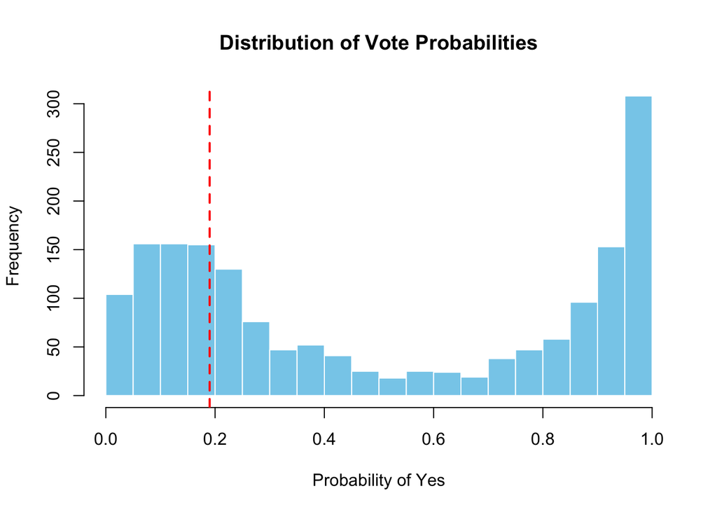

```r
# Get and plot votes distribution
votes <- rf_model_cv$finalModel$votes
votes_df <- data.frame(Probability = votes[, "Yes"])
hist(votes_df$Probability, breaks = 30, col = "skyblue", border = "white",
     main = "Distribution of Vote Probabilities", xlab = "Probability of Yes")
abline(v = 0.19, col = "red", lwd = 2, lty = 2)
```